# Worksheet 25 : Correlation and Linear Regression

Load data

```r
load("~/Documents/GitHub/MAT104-Spring24/Week-14/parenthood.Rdata")
```

### Caution

- Use caution when interpreting a pearson correlation coefficient.
- The correlation may not tell you what you think it does about the data.

Consider the following data set:

```r
cor(anscombe$x1,anscombe$y1)
```

```
## [1] 0.8164205
```

```r
# ggplot(anscombe, aes(x=x1,y=y1))+geom_point()
```

Now let’s check

```r
cor(anscombe$x2,anscombe$y2)
```

```
## [1] 0.8162365
```

- The same correlation coefficient! We should get a similar graph right?

```r
# ggplot(anscombe, aes(x=x2,y=y2))+geom_point()
```

```r
cor(anscombe$x3,anscombe$y3)
```

```
## [1] 0.8162867
```

```r
cor(anscombe$x4,anscombe$y4)
```

```
## [1] 0.8165214
```

```r
# ggplot(anscombe, aes(x=x3,y=y3))+geom_point()
# ggplot(anscombe, aes(x=x4,y=y4))+geom_point()
```

Notes:

## Linear Regression

Let’s go back to the parenthood data we used last class:

```r
ggplot(parenthood, aes(x=dan.sleep,y=dan.grump))+geom_point()
```

[output not shown]

The data looks like there is a linear relationship between `dan.sleep` and `dan.grump`, so let’s add a line to our plot that represents this relationship.

### Meaning of the Parameters

To make an equation for a line we use the slope-intercept formula:

$$y=mx+b$$
where $m$ is the slope of the line and $b$ is the $y$-intercept.

In statistics, we typically use different letters but the equation is the same:
$$\hat{Y_i} = b_1 X_i +
b_0$$
where $b_1$ is the slope and $b_0$ is the $y$-intercept. The values $b_1$ and $b_0$ are called coefficients.

1. Interpret $b_1$, $b_0$, $X_i$, and $\hat{Y}_i$ in the context of the parenthood data. Make a best guess for $b_0$ and $b_1$.

Answer here

```r
ggplot(parenthood, aes(x=dan.sleep,y=dan.grump)) +
  geom_point()
```

[output not shown]

- Notice that the points don’t all land directly on the line (in fact none of them do).
- So, when we plug an $X$ value into the line, all we get is a *prediction* of the $y$-value (this is why there is a hat on the $Y_i$ in the equation).

### Residuals

The graph below displays the error between our prediction and the true data in red:

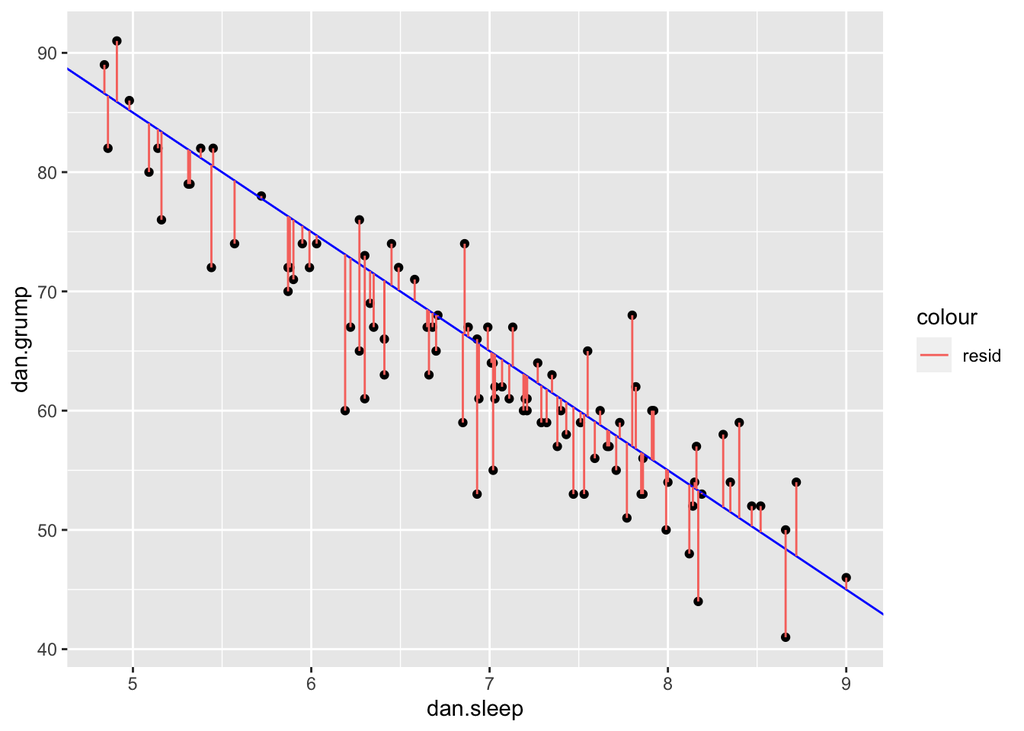

```r
# Use our slope and intercept guesses to predict the y-values
predictions <- data.frame(Y_hat = -10*parenthood$dan.sleep + 135)

# Plot segments joining the actual points and the predicted points
ggplot(parenthood, aes(x=dan.sleep,y=dan.grump)) +
  geom_point() +
  geom_abline(intercept = 135, slope = -10, color="blue") +
  geom_segment(aes(xend = dan.sleep, yend = predictions$Y_hat, color = "resid"))
```

$$\epsilon_i = Y_i -
\hat{Y}_i$$

## Minimizing error

- One approach for this is to minimize the so called **sum of the squared residuals**:

$$\sum \epsilon_i^2 = \sum (Y_i -
\hat{Y}_i)^2$$

- Find $\hat{b}_1$ and $\hat{b}_0$ so that…

### Using R to find the fits

```r
ggplot(parenthood, aes(x=dan.sleep,y=dan.grump))+geom_point()
```

[output not shown]

## Multiple Regression

The model we use for two predictors is:
$$\hat{Y}_i = b_2 X_{i,2} + b_1 X_{i,1} +
b_0$$

where $X_{i,2}$ is the amount of sleep the baby got on day $i$ and $X_{i,1}$ is the amount of sleep Danielle got on day $i$.

- If we had three predictors the equation would be:

$$\hat{Y}_i = b_3 X_{i,3} + b_2 X_{i,2} +
b_1 X_{i,1} + b_0$$

```r
# scatter3d(dan.grump ~ dan.sleep + baby.sleep, parenthood)
# rglwidget()
```

## Class Activity

1. Using the penguins data set, perform a simple linear regression to model body mass using the predictor variable bill length. What values do you get for $\hat{b}_0$ and $\hat{b}_1$? Graph a scatter plot for the data and include your regression model in the plot.

$\hat{b}_0 =$

$\hat{b}_1 =$

2. Use `cor()` to find the strength of the correlation between bill length and body mass.
3. Use simple linear regression to model the body mass of a penguin as predicted by the flipper length of a penguin. What values do you get for $\hat{b}_0$ and $\hat{b}_1$? Plot a scatter plot for the data with the line you found.

$\hat{b}_0 =$

$\hat{b}_1 =$

4. Use multiple linear regression to model the body mass using the predictors flipper length and bill length for the penguin data. Assuming $X_1$ is flipper length and $X_2$ is bill length, what values do you get for $\hat{b}_0$, $\hat{b}_1$, and $\hat{b}_2$?

$\hat{b}_0 =$

$\hat{b}_1 =$

$\hat{b}_2 =$